# Data Analysis Plan

Barracudas

28 February 2019

## Cluster analysis of multi-morbidity in UK Biobank participants

### Introduction

This data analysis plan describes the aims, methodology and outcomes that will be used for the cluster analysis of multi-morbidity in UK Biobank participants. These analyses will be carried out by the Barracudas (MSc Health Data Analytics and Machine Learning students).

[figure not shown]

### Aims

The overall objective of this study is to identify subsets of individuals suffering from multi-morbidity who share common environmental and/or biological pathways. To do this we are going to analyse UK Biobank participants. * We will identify sub-groups of individuals suffering from multi-morbidity * We will compare cluster analysis methods * We will attempt to identify possible shared and distinct underlying physio-pathological processes between clusters

### Dataset

UK Biobank data

UK UK Biobank is a prospective study investigating the contributions of genetic predisposition, and lifestyle and environmental exposures to the development of disease in 500 000 people aged 40-69 in the UK.

The dataset contains numerical, binary and categorical variables.

### Exploratory Data Analysis

- Dataset overview-table one (Josh)
  - Numbers of diseases across important epidemiological factors e.g. age, sex, smoking, alcohol:

Descriptive analysis table

|  | Female: 2 diseases | Male: 2 diseases | Female: 3 diseases | Male: 3 diseases | P value |
| --- | --- | --- | --- | --- | --- |
| n | 7124 | 10637 | 580 | 1108 |  |
| birth_year (mean (sd)) | 1948.4 (7.3) | 1947.3 (6.8) | 1947.3 (6.7) | 1946.3 (6.0) | <0.001 |
| BMI (mean (sd)) | 31.2 (6.6) | 30.2 (5.2) | 34.0 (7.0) | 31.8 (5.5) | <0.001 |
| current_smoker = 1 (%) | 861 (12.1) | 1427 (13.4) | 75 (12.9) | 156 (14.1) | 0.046 |
| current_etoh = 1 (%) | 5640 (79.2) | 9418 (88.5) | 389 (67.1) | 914 (82.5) | <0.001 |
| mi = 1 (%) | 956 (13.4) | 3445 (32.4) | 168 (29.0) | 558 (50.4) | <0.001 |
| angina = 1 (%) | 1839 (25.8) | 2554 (24.0) | 290 (50.0) | 396 (35.7) | <0.001 |
| stroke = 1 (%) | 1023 (14.4) | 1212 (11.4) | 122 (21.0) | 154 (13.9) | <0.001 |
| dvt_asthma_copd_atopy = 1 (%) | 6361 (89.3) | 8041 (75.6) | 580 (100.0) | 1108 (100.0) | <0.001 |
| diabetes = 1 (%) | 4069 (57.1) | 6022 (56.6) | 580 (100.0) | 1108 (100.0) | <0.001 |

- Plot distributions of diseases across important epidemiological factors

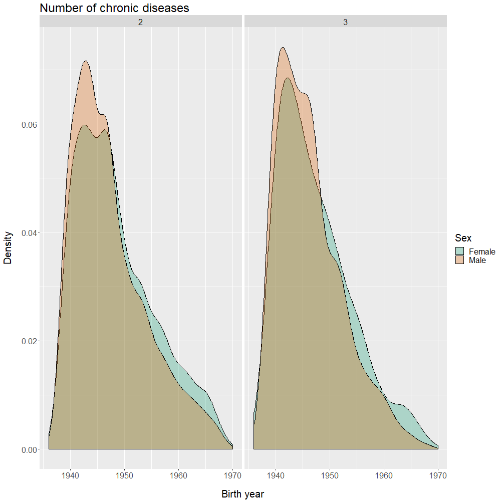

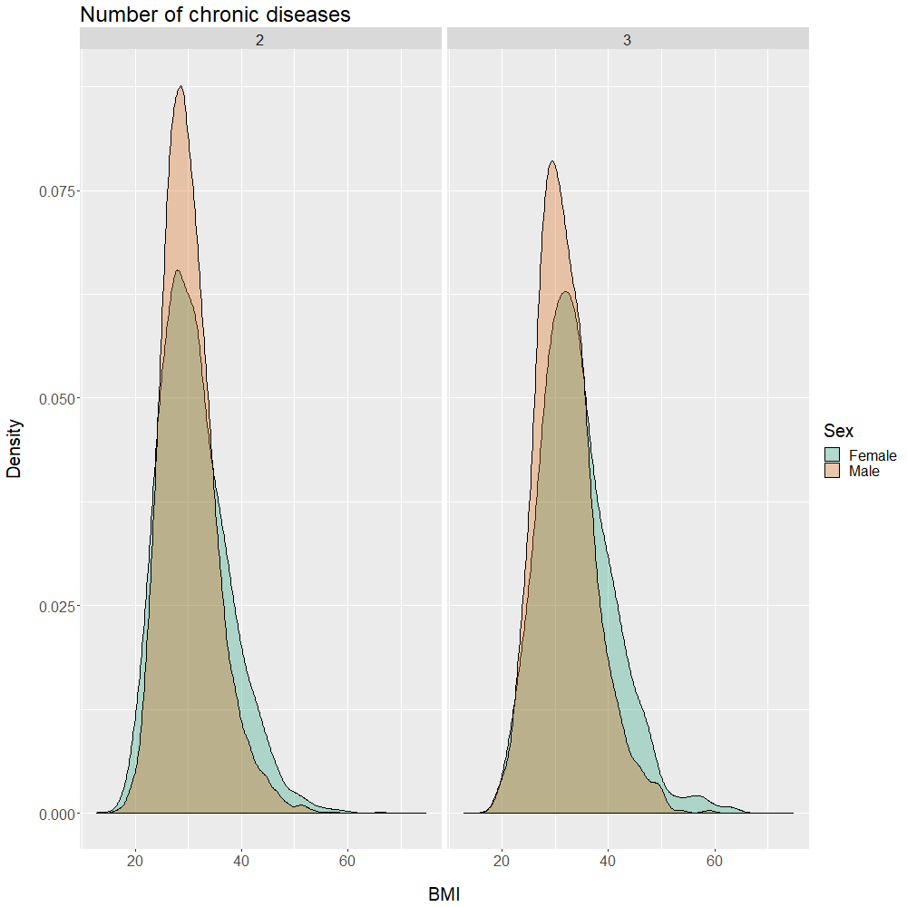

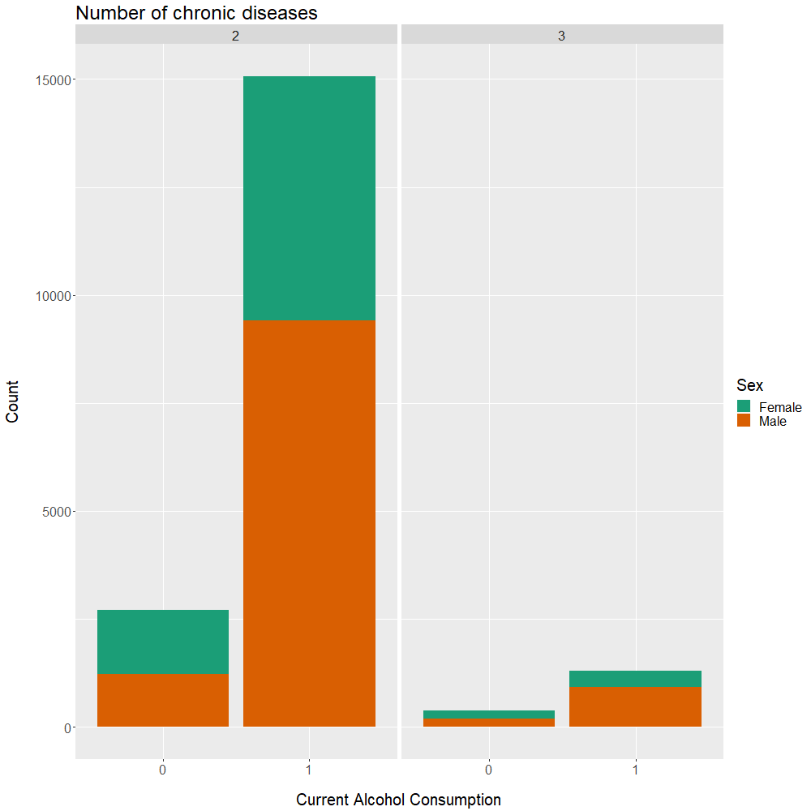

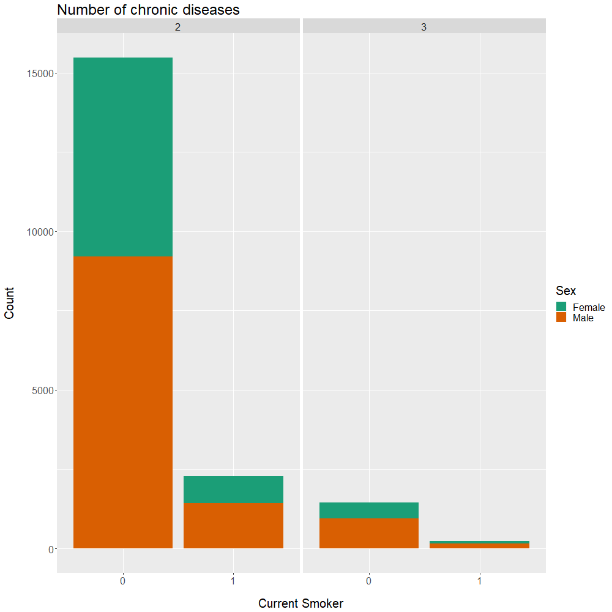

### Outcomes

- Clusters of Biobank participants with multi-morbidity (across different methods)
- Data similarity measures/distance metrics for clusters

## Clustering

### Algorithms

1. K Means (Everyone)
2. Partioning around Medoids (Joel)
3. DBSCAN (Joel)
4. Gaussian Mixture Models (Abi)
5. DIANA and hierarchical clustering with various linkage methods (Josh)

### Pre-Processing

Clustering methods require specific inputs to compute clusters Some only work with continuous features (kmeans) while others require a similarity/distance matrix. Almost none of the algorithms directly work with the initial mixed data

We have two approaches to our mixed data set, other than working straight on it

1. Make meaningful continuous features out of our dataset through adapted dimensionality reduction
2. Make meaningful similarity matrices out of the mixed data

#### Approach 1

Explore dimensionality reduction techniques for mixed datasets

- FAMD => Mixed PCA with FactoMineR package
- Auto-encoder => One hot encode everything and throw a neural network at it

#### Approach 2

- Use approach one then some distance matrix for continuous features
- Use Gower distance/random forests on the whole dataset to compute similarities from the mixed data

#### Pipelines Joel

- Kmeans (BASELINE = BAD)
- FAMD = > Kmeans
- Auto-Encoder => Kmeans
- RF => DBSCAN
- RF => PAM
- Gower distance matrix => PAM
- Gower distance matrix => DBSCAN
- Auto-Encoder => Some distance calculation => DBSCAN
- Auto-Encoder => Some distance calculation => PAM
- FAMD => Some distance calculation => PAM
- FAMD => Some distance calculation => DBSCAN

## Cluster Evaluation and Interpretation

### Cluster Evaluation

- Silhouette coefficient-how well defined are the clusters for each model
- Calinski-Harabasz criterion
- Interpretability of the clusters (this will be the big thing)

NOTE : Mathematical criteria all favour certain cluster shapes and thus need to be used carefully. They can be of good use to choose the number of clusters for the proper clustering method for example.

### Cluster Interpretation

- Dimensionality reduction and interpretation of coefficients
- Univariate tests for all variables?
- Interpretation plots?